# Communicate Data Findings (DataSet: Ford GoBike System Data)

## Preliminary Wrangling

**About Dataset:**

- This data set includes information about individual rides made in a bike-sharing system covering the greater San Francisco Bay area.

**Data Wrangling**

- Data wrangling consists of three phases and the whole process are iterative in any phase:
  - Gathering data.
  - Assessing data.
  - Cleaning data.

## 1. Gathering Data

- Load data from '201902-fordgobike-tripdata.csv'

```python
# import all packages and set plots to be embedded inline
import numpy as np
import pandas as pd
import matplotlib.pyplot as plt
import seaborn as sb

%matplotlib inline
sb.set()
```

```python
trips = pd.read_csv('./data/201902-fordgobike-tripdata.csv')
```

## 2. Assessing Data

- get info , stats about data

### Findings:

- Missing Values:
  - 'start_station_id', 'start_station_name', 'end_station_id' and 'end_station_name' columns have 197 null values that could be dropped
  - 'member_birth_year', 'member_gender' columns have 8265 null values
- Data Type:
  - 'start_station_id','end_station_id' should be integers
  - 'start_time', 'end_time' should be datetime
  - 'user_type','member_gender' should be categry
  - 'member_birth_year' should be int
- 'start_station_id' and 'start_station_id' columns could be dropped and replaced with 'start_station_name' and 'end_station_name'
- 'bike_id' and 'bike_share_for_all_trip' columns could be dropped as they are not having much impact in the trips (if we have db for bikes' specs could be useful to get more insights) and will not be interesting in the analysis

```python
print('no. of rows: {} \t\tno. of columns: {}'.format(trips.shape[0],trips.shape[1]),end='\n\n')
print('columns names: {}'.format(trips.columns))
trips.sample(10)
```

```
no. of rows: 183412 		no. of columns: 16

columns names: Index(['duration_sec', 'start_time', 'end_time', 'start_station_id',
       'start_station_name', 'start_station_latitude',
       'start_station_longitude', 'end_station_id', 'end_station_name',
       'end_station_latitude', 'end_station_longitude', 'bike_id', 'user_type',
       'member_birth_year', 'member_gender', 'bike_share_for_all_trip'],
      dtype='object')
```

|  | duration_sec | start_time | end_time | start_station_id | start_station_name | start_station_latitude | start_station_longitude | end_station_id | end_station_name | end_station_latitude | end_station_longitude | bike_id | user_type | member_birth_year | member_gender | bike_share_for_all_trip |
| --- | --- | --- | --- | --- | --- | --- | --- | --- | --- | --- | --- | --- | --- | --- | --- | --- |
| 127131 | 4091 | 2019-02-10 15:39:04.3130 | 2019-02-10 16:47:16.1710 | 8.0 | The Embarcadero at Vallejo St | 37.799953 | -122.398525 | 371.0 | Lombard St at Columbus Ave | 37.802746 | -122.413579 | 2271 | Customer | 2000.0 | Male | No |
| 75192 | 185 | 2019-02-19 09:22:41.4870 | 2019-02-19 09:25:47.1770 | 295.0 | William St at 10th St | 37.332794 | -121.875926 | 327.0 | 5th St at San Salvador St | 37.332039 | -121.881766 | 1492 | Subscriber | 1997.0 | Male | Yes |
| 86540 | 324 | 2019-02-17 12:37:57.6220 | 2019-02-17 12:43:22.1670 | 281.0 | 9th St at San Fernando St | 37.338395 | -121.880797 | 357.0 | 2nd St at Julian St | 37.341132 | -121.892844 | 6377 | Subscriber | 1994.0 | Male | Yes |
| 39264 | 319 | 2019-02-23 09:52:04.0410 | 2019-02-23 09:57:23.2950 | 252.0 | Channing Way at Shattuck Ave | 37.865847 | -122.267443 | 243.0 | Bancroft Way at College Ave | 37.869360 | -122.254337 | 6030 | Subscriber | 1990.0 | Male | No |
| 164980 | 514 | 2019-02-05 07:54:13.5720 | 2019-02-05 08:02:48.0480 | 30.0 | San Francisco Caltrain (Townsend St at 4th St) | 37.776598 | -122.395282 | 15.0 | San Francisco Ferry Building (Harry Bridges Pl... | 37.795392 | -122.394203 | 4941 | Subscriber | 1967.0 | Male | No |
| 176548 | 312 | 2019-02-02 11:10:36.8310 | 2019-02-02 11:15:49.0660 | 267.0 | Derby St at College Ave | 37.861804 | -122.253569 | 239.0 | Bancroft Way at Telegraph Ave | 37.868813 | -122.258764 | 4502 | Subscriber | 1983.0 | Female | No |
| 36118 | 1794 | 2019-02-23 16:34:00.9370 | 2019-02-23 17:03:55.3470 | 13.0 | Commercial St at Montgomery St | 37.794231 | -122.402923 | 74.0 | Laguna St at Hayes St | 37.776435 | -122.426244 | 6254 | Customer | 1990.0 | Male | No |
| 2580 | 468 | 2019-02-28 17:58:52.3530 | 2019-02-28 18:06:41.0900 | 36.0 | Folsom St at 3rd St | 37.783830 | -122.398870 | 67.0 | San Francisco Caltrain Station 2 (Townsend St... | 37.776639 | -122.395526 | 4973 | Subscriber | 1997.0 | Female | No |
| 105842 | 153 | 2019-02-13 20:20:30.3360 | 2019-02-13 20:23:03.9510 | 67.0 | San Francisco Caltrain Station 2 (Townsend St... | 37.776639 | -122.395526 | 90.0 | Townsend St at 7th St | 37.771058 | -122.402717 | 6280 | Subscriber | 1981.0 | Male | No |
| 167180 | 454 | 2019-02-04 17:37:56.8810 | 2019-02-04 17:45:31.4720 | 49.0 | S Park St at 3rd St | 37.780760 | -122.394989 | 324.0 | Union Square (Powell St at Post St) | 37.788300 | -122.408531 | 5218 | Subscriber | 1996.0 | Male | No |

```python
trips.info()
```

```
<class 'pandas.core.frame.DataFrame'>
RangeIndex: 183412 entries, 0 to 183411
Data columns (total 16 columns):
 #   Column                   Non-Null Count   Dtype
---  ------                   --------------   -----
 0   duration_sec             183412 non-null  int64
 1   start_time               183412 non-null  object
 2   end_time                 183412 non-null  object
 3   start_station_id         183215 non-null  float64
 4   start_station_name       183215 non-null  object
 5   start_station_latitude   183412 non-null  float64
 6   start_station_longitude  183412 non-null  float64
 7   end_station_id           183215 non-null  float64
 8   end_station_name         183215 non-null  object
 9   end_station_latitude     183412 non-null  float64
 10  end_station_longitude    183412 non-null  float64
 11  bike_id                  183412 non-null  int64
 12  user_type                183412 non-null  object
 13  member_birth_year        175147 non-null  float64
 14  member_gender            175147 non-null  object
 15  bike_share_for_all_trip  183412 non-null  object
dtypes: float64(7), int64(2), object(7)
memory usage: 22.4+ MB
```

```python
# getting stats about numeric columns
trips.describe().T
```

|  | count | mean | std | min | 25% | 50% | 75% | max |
| --- | --- | --- | --- | --- | --- | --- | --- | --- |
| duration_sec | 183412.0 | 726.078435 | 1794.389780 | 61.000000 | 325.000000 | 514.000000 | 796.000000 | 85444.000000 |
| start_station_id | 183215.0 | 138.590427 | 111.778864 | 3.000000 | 47.000000 | 104.000000 | 239.000000 | 398.000000 |
| start_station_latitude | 183412.0 | 37.771223 | 0.099581 | 37.317298 | 37.770083 | 37.780760 | 37.797280 | 37.880222 |
| start_station_longitude | 183412.0 | -122.352664 | 0.117097 | -122.453704 | -122.412408 | -122.398285 | -122.286533 | -121.874119 |
| end_station_id | 183215.0 | 136.249123 | 111.515131 | 3.000000 | 44.000000 | 100.000000 | 235.000000 | 398.000000 |
| end_station_latitude | 183412.0 | 37.771427 | 0.099490 | 37.317298 | 37.770407 | 37.781010 | 37.797320 | 37.880222 |
| end_station_longitude | 183412.0 | -122.352250 | 0.116673 | -122.453704 | -122.411726 | -122.398279 | -122.288045 | -121.874119 |
| bike_id | 183412.0 | 4472.906375 | 1664.383394 | 11.000000 | 3777.000000 | 4958.000000 | 5502.000000 | 6645.000000 |
| member_birth_year | 175147.0 | 1984.806437 | 10.116689 | 1878.000000 | 1980.000000 | 1987.000000 | 1992.000000 | 2001.000000 |

```python
#check missing values in df
trips.isnull().sum()
```

```
duration_sec                  0
start_time                    0
end_time                      0
start_station_id            197
start_station_name          197
start_station_latitude        0
start_station_longitude       0
end_station_id              197
end_station_name            197
end_station_latitude          0
end_station_longitude         0
bike_id                       0
user_type                     0
member_birth_year          8265
member_gender              8265
bike_share_for_all_trip       0
dtype: int64
```

```python
#check duplicates in df
trips.duplicated().sum()
```

```
0
```

```python
#findings for columns : 'duration_sec'

print(trips['duration_sec'].value_counts(dropna=False).sort_index(), end='\n\n')
print(trips['duration_sec'].describe(), end='\n\n')
print(trips['duration_sec'].isnull().any(), end='\n\n')
```

```
61       18
62       22
63       27
64       18
65       25
         ..
83407     1
83519     1
83772     1
84548     1
85444     1
Name: duration_sec, Length: 4752, dtype: int64

count    183412.000000
mean        726.078435
std        1794.389780
min          61.000000
25%         325.000000
50%         514.000000
75%         796.000000
max       85444.000000
Name: duration_sec, dtype: float64

False
```

```python
#findings for columns : 'start_time', 'end_time'

# print(trips.start_time.value_counts(dropna=False))
print('Min Start Time: {}'.format(trips.start_time.min()))
print('Max Start Time: {}'.format(trips.start_time.max()))
print('No. of Unique Start Time: {}'.format(trips.start_time.nunique()))
print('Type of Start Time Column : {}'.format(trips.start_time.dtype) , end='\n\n')

# print(trips.end_time.value_counts(dropna=False))
print('Min End Time: {}'.format(trips.end_time.min()))
print('Max End Time: {}'.format(trips.end_time.max()))
print('No. of Unique End Time: {}'.format(trips.end_time.nunique()))
print('Type of End Time Column : {}'.format(trips.end_time.dtype))
```

```
Min Start Time: 2019-02-01 00:00:20.6360
Max Start Time: 2019-02-28 23:59:18.5480
No. of Unique Start Time: 183401
Type of Start Time Column : object

Min End Time: 2019-02-01 00:04:52.0580
Max End Time: 2019-03-01 08:01:55.9750
No. of Unique End Time: 183397
Type of End Time Column : object
```

```python
#findings for columns : 'start_station_id','start_station_name','end_station_id','end_station_name',

print(trips['start_station_name'].value_counts(dropna=False),end='\n\n')
print(trips['end_station_name'].value_counts(dropna=False),end='\n\n')
```

```
Market St at 10th St                                         3904
San Francisco Caltrain Station 2  (Townsend St at 4th St)    3544
Berry St at 4th St                                           3052
Montgomery St BART Station (Market St at 2nd St)             2895
Powell St BART Station (Market St at 4th St)                 2760
                                                             ...
Willow St at Vine St                                            9
Parker Ave at McAllister St                                     7
Palm St at Willow St                                            4
21st Ave at International Blvd                                  4
16th St Depot                                                   2
Name: start_station_name, Length: 330, dtype: int64

San Francisco Caltrain Station 2  (Townsend St at 4th St)    4857
Market St at 10th St                                         3973
Montgomery St BART Station (Market St at 2nd St)             3647
San Francisco Ferry Building (Harry Bridges Plaza)           3368
Powell St BART Station (Market St at 4th St)                 2997
                                                             ...
Parker Ave at McAllister St                                     9
Palm St at Willow St                                            7
21st Ave at International Blvd                                  6
16th St Depot                                                   6
Willow St at Vine St                                            5
Name: end_station_name, Length: 330, dtype: int64
```

```python
# start station lat/long missing names
print(trips.loc[trips['start_station_name'].isnull(),'start_station_latitude'].value_counts() ,end= '\n\n')
print(trips.loc[trips['start_station_name'].isnull(),'start_station_longitude'].value_counts() ,end= '\n\n')
```

```
37.41    101
37.40     63
37.42     21
37.39     11
37.38      1
Name: start_station_latitude, dtype: int64

-121.94    57
-121.96    46
-121.93    46
-121.95    37
-121.92    10
-121.98     1
Name: start_station_longitude, dtype: int64
```

```python
# end station lat/long missing names
print(trips.loc[trips['end_station_name'].isnull(),'end_station_latitude'].value_counts() ,end= '\n\n')
print(trips.loc[trips['end_station_name'].isnull(),'end_station_longitude'].value_counts() ,end= '\n\n')
```

```
37.41    98
37.40    65
37.42    18
37.39    13
37.38     2
37.43     1
Name: end_station_latitude, dtype: int64

-121.94    55
-121.93    50
-121.96    46
-121.95    33
-121.92    11
-121.98     2
Name: end_station_longitude, dtype: int64
```

```python
#findings for columns : 'user_type'

print(trips.user_type.value_counts(dropna=False))
print(trips.user_type.dtype)
```

```
Subscriber    163544
Customer       19868
Name: user_type, dtype: int64
object
```

```python
#findings for columns : ''member_birth_year','member_gender'

print('Min Birth Year: {}'.format(trips.member_birth_year.min()))
print('Max Birth Year: {}'.format(trips.member_birth_year.max()))
print('No. of Unique Birth Year: {}'.format(trips.member_birth_year.nunique()))
print('Type of Start Birth Year: {}'.format(trips.member_birth_year.dtype) , end='\n\n')

print(trips.member_gender.value_counts(dropna=False))
print(trips.member_gender.dtype)
```

```
Min Birth Year: 1878.0
Max Birth Year: 2001.0
No. of Unique Birth Year: 75
Type of Start Birth Year: float64

Male      130651
Female     40844
NaN         8265
Other       3652
Name: member_gender, dtype: int64
object
```

## 3. Data Cleaning

```python
# getting copy of the original data
trips_clean = trips.copy()
```

```python
# dropping 'start_station_id', 'end_station_id', 'bike_id', 'bike_share_for_all_trip' columns
trips_clean = trips.drop(['start_station_id', 'end_station_id','bike_id', 'bike_share_for_all_trip'],axis=1);

trips_clean.columns
```

```
Index(['duration_sec', 'start_time', 'end_time', 'start_station_name',
       'start_station_latitude', 'start_station_longitude', 'end_station_name',
       'end_station_latitude', 'end_station_longitude', 'user_type',
       'member_birth_year', 'member_gender'],
      dtype='object')
```

```python
# dropping rows with Missing values
trips_clean.dropna(inplace=True )
trips_clean.isnull().any()
```

```
duration_sec               False
start_time                 False
end_time                   False
start_station_name         False
start_station_latitude     False
start_station_longitude    False
end_station_name           False
end_station_latitude       False
end_station_longitude      False
user_type                  False
member_birth_year          False
member_gender              False
dtype: bool
```

```python
# converting 'start_time', 'end_time' to datetime column
trips_clean['start_time'] = pd.to_datetime(trips_clean['start_time'])
trips_clean['end_time'] = pd.to_datetime(trips_clean['end_time'])

# converting 'member_birth_year' to int column
trips_clean['member_birth_year'] = trips_clean['member_birth_year'].astype(int)

# converting 'user_type','member_gender' to category column
trips_clean[['user_type','member_gender']] = trips_clean[['user_type','member_gender']].astype('category')

trips_clean.dtypes
```

```
duration_sec                        int64
start_time                 datetime64[ns]
end_time                   datetime64[ns]
start_station_name                 object
start_station_latitude            float64
start_station_longitude           float64
end_station_name                   object
end_station_latitude              float64
end_station_longitude             float64
user_type                        category
member_birth_year                   int32
member_gender                    category
dtype: object
```

```python
# saving clean data
trips_clean.to_csv('./data/trips_data_clean.csv',index=False)
```

```python
trips_clean.info()
```

```
<class 'pandas.core.frame.DataFrame'>
Int64Index: 174952 entries, 0 to 183411
Data columns (total 12 columns):
 #   Column                   Non-Null Count   Dtype
---  ------                   --------------   -----
 0   duration_sec             174952 non-null  int64
 1   start_time               174952 non-null  datetime64[ns]
 2   end_time                 174952 non-null  datetime64[ns]
 3   start_station_name       174952 non-null  object
 4   start_station_latitude   174952 non-null  float64
 5   start_station_longitude  174952 non-null  float64
 6   end_station_name         174952 non-null  object
 7   end_station_latitude     174952 non-null  float64
 8   end_station_longitude    174952 non-null  float64
 9   user_type                174952 non-null  category
 10  member_birth_year        174952 non-null  int32
 11  member_gender            174952 non-null  category
dtypes: category(2), datetime64[ns](2), float64(4), int32(1), int64(1), object(2)
memory usage: 14.3+ MB
```

```python
trips_clean.describe().T
```

|  | count | mean | std | min | 25% | 50% | 75% | max |
| --- | --- | --- | --- | --- | --- | --- | --- | --- |
| duration_sec | 174952.0 | 704.002744 | 1642.204905 | 61.000000 | 323.000000 | 510.000000 | 789.000000 | 84548.000000 |
| start_station_latitude | 174952.0 | 37.771220 | 0.100391 | 37.317298 | 37.770407 | 37.780760 | 37.797320 | 37.880222 |
| start_station_longitude | 174952.0 | -122.351760 | 0.117732 | -122.453704 | -122.411901 | -122.398279 | -122.283093 | -121.874119 |
| end_station_latitude | 174952.0 | 37.771414 | 0.100295 | 37.317298 | 37.770407 | 37.781010 | 37.797673 | 37.880222 |
| end_station_longitude | 174952.0 | -122.351335 | 0.117294 | -122.453704 | -122.411647 | -122.397437 | -122.286533 | -121.874119 |
| member_birth_year | 174952.0 | 1984.803135 | 10.118731 | 1878.000000 | 1980.000000 | 1987.000000 | 1992.000000 | 2001.000000 |

### What is the structure of your dataset?

> The Dataset Contains 183412 row and 16 columns and all data belongs to Feb 2019 after basic data cleaning
> - dropping entries with null values.
> - dropping columns with names (start_station_id, end_station_id) as they could be replaced with station names.
> - dropping columns with names (bike_id, bike_share_for_all_trip) as thery are not interesting in the analysis.

> Now The Dataset contains 174952 row with 12 Column

### What is/are the main feature(s) of interest in your dataset?

> I'm interested in figuring out the factors that affect the most on the ride duration and these questions will help with that:
> - When are most trips taken in terms of time of day, day of the week?
> - How long does the average trip take?
> - Does the trip duration depend on user type (subscriber or customer)?
> - Does the trip duration depend on member gender (male or female)?
> - Does the trip duration depend on member age?

### What features in the dataset do you think will help support your investigation into your feature(s) of interest?

> I thinks these features will be interesting in the investigation:
> - 'start_time': help to get hour, day for trips.
> - 'start_station_latitude', 'start_station_longitude', 'end_station_latitude', 'end_station_longitude' : help to calculate the total distance between start and end points.
> - 'user_type': help to check if there are correlation between user type and trip duration.
> - 'member_gender': help to check if there are correlation between user gender type and trip duration.
> - 'member_birth_year' : help to get member age and check if it has correlation with trips duration.

```python
# getting the hour , day From start_time
trips_clean['start_hour'] = trips_clean['start_time'].dt.hour
trips_clean['start_day'] = trips_clean['start_time'].dt.day_name()
```

```python
print(trips_clean['start_hour'].value_counts().sort_index(), end='\n\n')
print(trips_clean['start_day'].value_counts())
```

```
0       893
1       525
2       355
3       164
4       227
5       866
6      3293
7     10231
8     20227
9     15204
10     7970
11     7461
12     8220
13     8098
14     7677
```

[output cut: 19 more lines]

```python
# getting the total distance from long and lat
import math

def getDistanceKM(start_point_lat , start_point_long, end_point_lat, end_point_long):
    # approximate radius of earth in km
    R = 6373.0

    # coordinates
    lat1 = math.radians(start_point_lat)
    lon1 = math.radians(start_point_long)
    lat2 = math.radians(end_point_lat)
    lon2 = math.radians(end_point_long)

    # change in coordinates
    dlon = lon2 - lon1
    dlat = lat2 - lat1

    # Haversine formula
    a = math.sin(dlat / 2)**2 + math.cos(lat1) * math.cos(lat2) * math.sin(dlon / 2)**2
    c = 2 * math.atan2(math.sqrt(a), math.sqrt(1 - a))

    return R * c

trips_clean['distance_km'] = trips_clean.apply(lambda x : getDistanceKM(x['start_station_latitude'],x['start_station_longitude'],x['end_station_latitude'],x['end_station_longitude']),axis=1)
trips_clean['distance_km'].value_counts()
```

```
0.000000    3458
1.035914     591
2.172215     493
1.349635     491
1.413991     474
            ...
4.281357       1
6.784834       1
6.125572       1
2.708061       1
4.939688       1
Name: distance_km, Length: 13760, dtype: int64
```

```python
# getting the age from member_birth_year
trips_clean['member_age'] = 2019 - trips_clean['member_birth_year']
trips_clean['member_age'].value_counts().sort_index()
```

```
18       34
19     1675
20     2504
21     3208
22     3476
       ...
109       1
117      11
118       6
119      53
141       1
Name: member_age, Length: 75, dtype: int64
```

```python
trips_clean['duration'] = trips_clean['duration_sec'] / 60
trips_clean['duration'].value_counts().sort_index()
```

```
1.016667       18
1.033333       19
1.050000       22
1.066667       17
1.083333       22
               ..
1375.200000     1
1386.583333     1
1390.116667     1
1391.983333     1
1409.133333     1
Name: duration, Length: 4429, dtype: int64
```

```python
# dropping unneeded columns in the analysis
trips_clean.drop(columns=['duration_sec','start_time', 'end_time','start_station_latitude', 'start_station_longitude','end_station_latitude', 'end_station_longitude','member_birth_year'],axis=1,inplace=True)
trips_clean.columns
```

```
Index(['start_station_name', 'end_station_name', 'user_type', 'member_gender',
       'start_hour', 'start_day', 'distance_km', 'member_age', 'duration'],
      dtype='object')
```

```python
trips_clean.to_csv('./data/trips_data_modified.csv',index=False)
```

## Univariate Exploration

> In this section, I will investigate distributions of individual variables.
> - Distribution of the trip duration
> - Distribution of the distance_km
> - Distribution of the Trips start_hour
> - Distribution of the Trips start_day
> - Distribution of the user_type
> - Distribution of the member_gender
> - Distribution of the member_age

```python
def getOutliers(df,column_name):
    # Calculate IQR
    Q1 = df[column_name].quantile(0.25)
    Q3 = df[column_name].quantile(0.75)
    IQR = Q3 - Q1

    higher_outliers = df[column_name] > (Q3 + (1.5*IQR))
    lower_outliers = df[column_name] < (Q1 - (1.5*IQR))
    outliers = df.loc[ higher_outliers | lower_outliers , column_name]
    return outliers
```

### Distribution of the Trip Duration

- The data is right skewed with many outliers and 75% trips are under ~ 13.15 min
- trips with duration greater than or equal ~ 24.81 min could be considered outliers
- the average trip duration after excluding outliers is ~ 9.17 min

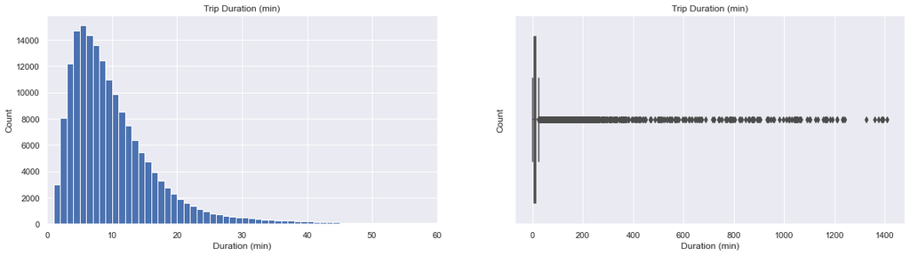

```python
plt.figure(figsize = [20, 5])
base_color = sb.color_palette()[0]

plt.subplot(1, 2, 1)
bins = np.arange(0, trips_clean['duration'].max()+1, 1)
plt.hist(data = trips_clean, x = 'duration', bins = bins)
plt.xlim([0,60]);
plt.xlabel('Duration (min)')
plt.ylabel('Count')
plt.title("Trip Duration (min)");

plt.subplot(1, 2, 2)
sb.boxplot(data=trips_clean, x='duration')
plt.xlabel('Duration (min)')
plt.ylabel('Count')
plt.title('Trip Duration (min)');
```

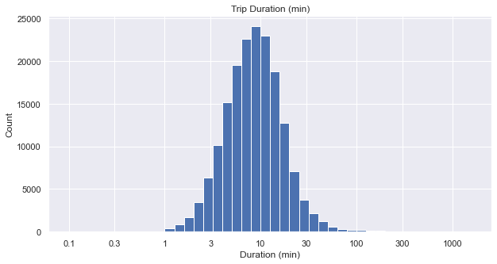

```python
#duration on log scale
plt.figure(figsize= (10,5))

bins = 10 ** np.arange(-1, np.log10(trips_clean['duration'].max())+0.1, 0.1)
ticks = [0.1, 0.3, 1, 3, 10, 30, 100, 300, 1000]
labels = ['{}'.format(val) for val in ticks]
plt.hist(data = trips_clean, x = 'duration', bins = bins)
plt.xscale('log')
plt.xticks(ticks, labels)
plt.xlabel('Duration (min)')
plt.ylabel('Count')
plt.title('Trip Duration (min)');
```

```python
trips_clean['duration'].describe()
```

```
count    174952.000000
mean         11.733379
std          27.370082
min           1.016667
25%           5.383333
50%           8.500000
75%          13.150000
max        1409.133333
Name: duration, dtype: float64
```

```python
#getting trip duration outliesr
duration_outliers = getOutliers(trips_clean,'duration')
duration_outliers.value_counts().sort_index()
```

```
24.816667      15
24.833333      11
24.850000      15
24.866667      12
24.883333      10
               ..
1375.200000     1
1386.583333     1
1390.116667     1
1391.983333     1
1409.133333     1
Name: duration, Length: 3001, dtype: int64
```

```python
#getting average trip duration after removing outliers
trips_clean.loc[trips_clean['duration']< duration_outliers.min() , 'duration'].mean()
```

```
9.170097328889645
```

### Distribution of the Distance

- the majority of trips distance between 0 and 2 km , 75% of the trips within ~ 2.22 km
- we could consider trips with distance more than or equal ~ 4.19 km outliers
- the average trip distance after removing outliers is ~ 1.58 km.

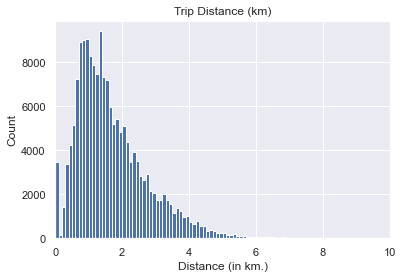

```python
bins = np.arange(0, trips_clean['distance_km'].max()+0.1, 0.1)
plt.hist(data = trips_clean, x = 'distance_km', bins = bins)
plt.xlim([0,10]);
plt.xlabel('Distance (in km.)')
plt.ylabel('Count')
plt.title("Trip Distance (km)");
```

```python
trips_clean['distance_km'].describe()
```

```
count    174952.000000
mean          1.690580
std           1.097301
min           0.000000
25%           0.910729
50%           1.430278
75%           2.224708
max          69.491049
Name: distance_km, dtype: float64
```

```python
#getting trip distance outliers
distance_outliers = getOutliers(trips_clean,'distance_km')
distance_outliers.value_counts().sort_index()
```

```
4.196288     15
4.197722      2
4.198855      2
4.199672      1
4.200299      1
             ..
13.595110     1
13.898824     1
14.104136     1
15.678876     1
69.491049     1
Name: distance_km, Length: 1585, dtype: int64
```

```python
#getting average trip distance after removing outliers
trips_clean.loc[trips_clean['distance_km']< distance_outliers.min() , 'distance_km'].mean()
```

```
1.5849704660168873
```

### Distribution of the Trips Start_Time (Days, Hours )

- For Hour : there are two peaks for start_hour at 8 am and 5 pm ,almost start and end of the working hours
- For days as expected the weekends have the minor rate for starting trips

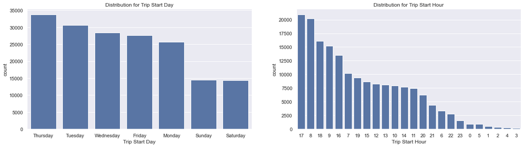

```python
plt.figure(figsize = [20, 5])

# plotting distribution of days
plt.subplot(1, 2, 1)
sb.countplot(data=trips_clean , x='start_day',color=base_color , order=trips_clean['start_day'].value_counts().index)
plt.xlabel('Trip Start Day')
plt.title('Distribution for Trip Start Day');

# plotting distribution of hours
plt.subplot(1, 2, 2)
sb.countplot(data=trips_clean , x='start_hour',color=base_color , order=trips_clean['start_hour'].value_counts().index)
plt.xlabel('Trip Start Hour')
plt.title('Distribution for Trip Start Hour');
```

## Distribution of the User_Type

- The Majority of users are subscribers and only 9.5% are Customers

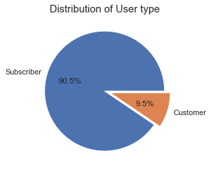

```python
data = trips_clean['user_type'].value_counts(normalize=True)
plt.pie(x=data  ,labels=data.index, explode=(0,0.1) ,autopct='%.1f%%')
plt.title("Distribution of User type", fontsize=15);
```

### Distribution of the member_gender

- The Majority of users are Males , About ~ 75% of members are Male

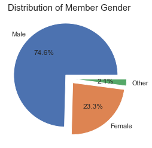

```python
data = trips_clean['member_gender'].value_counts(normalize=True)
plt.pie(x=data  ,labels=data.index, explode=[0.1]*3,autopct='%.1f%%')
plt.title("Distribution of Member Gender",fontsize=15);
```

### Distribution of the member_age

- the most members have ages between 25 and 35 , 75% of users less than or equal 39 years
- we could consider members with age greater than or equal 58 outliers
- the average member age after removing outliers is 33

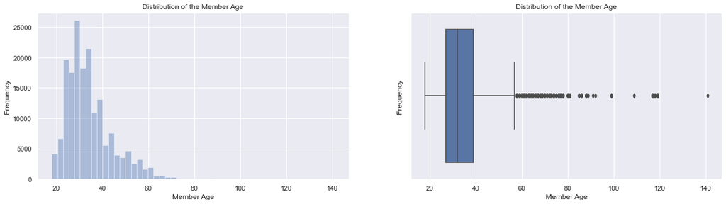

```python
plt.figure(figsize = [20, 5])

# plotting distribution of days
plt.subplot(1, 2, 1)
sb.distplot(trips_clean['member_age'], kde=False)
plt.xlabel('Member Age')
plt.ylabel('Frequency')
plt.title('Distribution of the Member Age');

plt.subplot(1, 2, 2)
sb.boxplot(data=trips_clean, x='member_age')
plt.xlabel('Member Age')
plt.ylabel('Frequency')
plt.title('Distribution of the Member Age');
```

```python
trips_clean['member_age'].describe()
```

```
count    174952.000000
mean         34.196865
std          10.118731
min          18.000000
25%          27.000000
50%          32.000000
75%          39.000000
max         141.000000
Name: member_age, dtype: float64
```

```python
#getting member age outliesr
age_outliers = getOutliers(trips_clean,'member_age')
age_outliers.value_counts().sort_index()
```

```
58     821
59     806
60     624
61     517
62     807
63     392
64     134
65     301
66     158
67     189
68     180
69     178
70      99
71      51
72     135
```

[output cut: 21 more lines]

```python
#getting average member age after removing outliers
trips_clean.loc[trips_clean['member_age']< age_outliers.min() , 'member_age'].mean()
```

```
33.185557808371414
```

### Discuss the distribution(s) of your variable(s) of interest. Were there any unusual points? Did you need to perform any transformations?

- For Trip Duration , the distribution is right skewed with may outliers , after calculating the outliers based on 1.5*IQR Rule we could consider trips with duration more than 25 min outliers.
- Yes, when plotting duration on a log-scale the duration distribution looks unimodal.

### Of the features you investigated, were there any unusual distributions? Did you perform any operations on the data to tidy, adjust, or change the form of the data? If so, why did you do this?

- Almost all distributions for features invistigated was reasonable and expected.
- Yes , many features has been changed to fix quality or tidy issues or to get more insights
  - duration_sec : converted to minutes
  - start_time : used to get hour and day of trips
  - long,lat for start and end stations : used to get the total distance
  - member birth year : used to get the member ages

## Bivariate Exploration

> In this section, investigate relationships between pairs of variables in your data.
- The relationship between the user type and the duration trip
- The relationship between the member gender and the duration trip
- The relationship between the member age and the duration trip
- The relationship between Member gender and User Type
- The relationship between start hour and User Type
- The relationship between start day and User Type
- The relationship between trip start hour and trip duration
- The relationship between trip start day and trip duration

## The relationship between the user type and the duration trip

- the figure shows that customer users on average have longer trip than subscriber ones

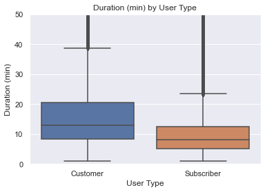

```python
sb.boxplot(data=trips_clean, x='user_type', y='duration')
plt.ylim(0, 50);
plt.ylabel('Duration (min)')
plt.xlabel('User Type')
plt.title('Duration (min) by User Type');
```

```python
df = trips_clean.loc[trips_clean['duration']< duration_outliers.min() , ['user_type','duration']]
df.groupby('user_type')['duration'].mean()
```

```
user_type
Customer      11.946142
Subscriber     8.920141
Name: duration, dtype: float64
```

## The relationship between the member gender and the duration trip

- the figure shows that Female users on average have slightly longer trip than Males

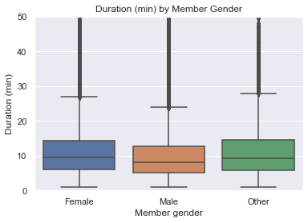

```python
sb.boxplot(data=trips_clean, x='member_gender', y='duration')
plt.ylim(0, 50);
plt.ylabel('Duration (min)')
plt.xlabel('Member gender')
plt.title('Duration (min) by Member Gender');
```

```python
df = trips_clean.loc[trips_clean['duration']< duration_outliers.min() , ['member_gender','duration']]
df.groupby('member_gender')['duration'].mean()
```

```
member_gender
Female    9.903278
Male      8.934622
Other     9.546023
Name: duration, dtype: float64
```

## The relationship between the member age and the duration trip

- the figure shows that there is no strong pattern/correlation between age and trip duration

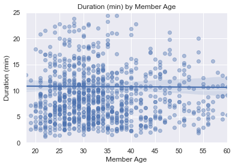

```python
sb.regplot(data = trips_clean.sample(1000), x = 'member_age', y = 'duration',scatter_kws= {'alpha': 0.4});

# min age in dataset is 18 and age outliers >= 58
plt.xlim(18,60)
plt.xlabel('Member Age')

# duration outliers >= 25
plt.ylim(0,25)
plt.ylabel('Duration (min)')

plt.title('Duration (min) by Member Age');
```

```python
trips_clean[['member_age', 'duration']].corr()
```

|  | member_age | duration |
| --- | --- | --- |
| member_age | 1.000000 | 0.006041 |
| duration | 0.006041 | 1.000000 |

## The relationship between the member gender and the user type

- the figure shows that most subscribers are males

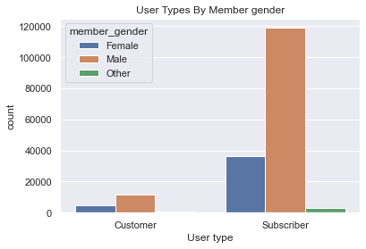

```python
sb.countplot(data=trips_clean , x= 'user_type', hue='member_gender');
plt.xlabel('User type')
plt.title('User Types By Member gender');
```

```python
trips_clean.groupby('user_type')['member_gender'].value_counts(normalize=True)
```

```
user_type   member_gender
Customer    Male             0.693770
            Female           0.279066
            Other            0.027164
Subscriber  Male             0.751373
            Female           0.228442
            Other            0.020185
Name: member_gender, dtype: float64
```

## The relationship between the trip start hour and the user type

- the main diffrence between subscribers and customers between 10am and 4pm , in this period the trip counts for customers increased but for subscribers stay in close range.

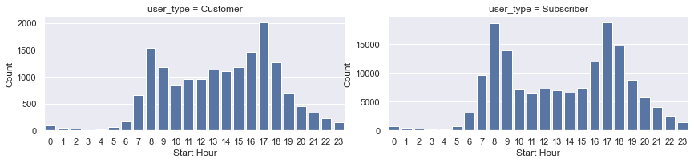

```python
# Plot the Seaborn's FacetGrid
g = sb.FacetGrid(data = trips_clean, col = 'user_type', col_wrap=2, aspect=2, sharey=False)
g = g.map(sb.countplot, 'start_hour' ,order =range(0,24,1) );

for i in range(2):
    g.axes[i].set_xlabel('Start Hour')
    g.axes[i].set_ylabel('Count')
```

## The relationship between the trip start day and the user type

- the trips count for subscribes decrease in weekends
- For customers , the trips counts almost in the same range for all day

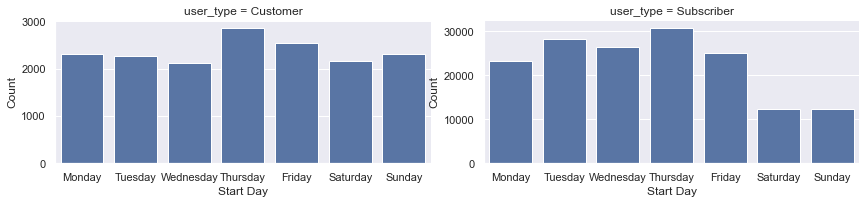

```python
days_order = ['Monday','Tuesday','Wednesday','Thursday','Friday','Saturday','Sunday']
# Plot the Seaborn's FacetGrid
g = sb.FacetGrid(data = trips_clean, col = 'user_type', col_wrap=2, aspect=2, sharey=False)
g = g.map(sb.countplot, 'start_day' ,order=days_order);

for i in range(2):
    g.axes[i].set_xlabel('Start Day')
    g.axes[i].set_ylabel('Count')
```

## The relationship between the trip start hour and the duration trip

- the figure shows that there are no strong pattern/correlation between start_hour and trip duration4

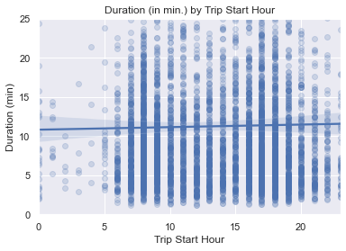

```python
sb.regplot(data = trips_clean.sample(5000), x = 'start_hour', y = 'duration',scatter_kws= {'alpha': 0.2});
plt.ylim(0,25)
plt.ylabel('Duration (min)')

plt.xlabel('Trip Start Hour')
plt.title('Duration (in min.) by Trip Start Hour');
```

```python
trips_clean[['start_hour','duration']].corr()
```

|  | start_hour | duration |
| --- | --- | --- |
| start_hour | 1.000000 | 0.006118 |
| duration | 0.006118 | 1.000000 |

## The relationship between the trip start day and the duration trip

- the figure shows that on average trips started in weekends (saturday/sunday) have longer duration.

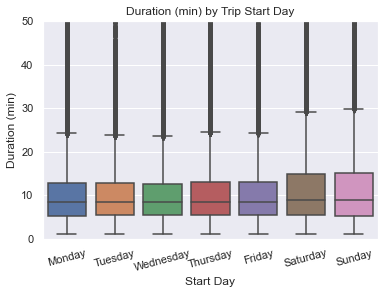

```python
sb.boxplot(data=trips_clean, x='start_day', y='duration', order=days_order)
plt.ylim(0, 50);
plt.ylabel('Duration (min)')

plt.xticks(rotation=15)
plt.xlabel('Start Day')

plt.title('Duration (min) by Trip Start Day');
```

```python
trips_clean.groupby('start_day')['duration'].mean()
```

```
start_day
Friday       11.354578
Monday       11.616182
Saturday     14.162862
Sunday       14.311227
Thursday     11.304829
Tuesday      10.880658
Wednesday    11.085466
Name: duration, dtype: float64
```

### Talk about some of the relationships you observed in this part of the investigation. How did the feature(s) of interest vary with other features in the dataset?

**For trip duration :**

- **The relationship between the user type and the duration trip**
  - customers have longer trip duration than subscribers.
- **The relationship between the member gender and the duration trip**
  - unlike expected, Females have slightly longer trip duration than males.
- **The relationship between the member age and the duration trip**
  - I expected that younger ages will have trips with longer duration but unlike expected no strong correlation detected from the figure, different ages have the same distribution for trip duration.
- **The relationship between the trip start hour and the duration trip**
  - no strong correlation detected from the figure. almost all day hours have the same distribution for trip duration.
- **The relationship between the trip start day and the duration trip**
  - Saturday and Sunday (weekends) have on average trips with longer duration than week days.

### Did you observe any interesting relationships between the other features (not the main feature(s) of interest)?

- **The relationship between the member gender and the user type**
  - subscribers are 75% males and 22% females , but it could be as the data set itself have almost 75% males and 23% females.
- **The relationship between trip start hour and the user type**
  - I expected that during working hours customers will be more active. and the figure shows that almost subscribers and customers have the same distribution except from 10am and 4pm , customers satrted more trips like expected.
- **For The relationship between trip start day and the user type**
  - I expected that both customers and subscribers number of trips will decrease in the weekends, despite of the subscribers trips decrease but unlike expected the customers trips for all days have almost the same distribution.

## Multivariate Exploration

> Create plots of three or more variables to investigate your data even further.
- the relation between user type, member gender and trip duration
- the relation between member age, member gender and trip duration
- the relation between start day, member gender and trip duration
- the relation between start hour, member gender and trip duration
- the relation between user type, start hour and start day

## the relation between user type, member gender and trip duration

- the figure emphasize that customers have longer trips (for both males and females)

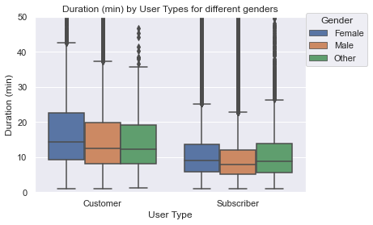

```python
sb.boxplot(data= trips_clean, x = 'user_type', y= 'duration', hue= 'member_gender')
plt.ylim(0,50)
plt.ylabel('Duration (min)')
plt.xlabel('User Type')
plt.title('Duration (min) by User Types for different genders')
plt.legend(loc = [1,0.72], title= 'Gender');
```

## the relation between member age, member gender and trip duration

- the figure shows that there is no strong correlation betweeen age and trip duration (for both males and females)

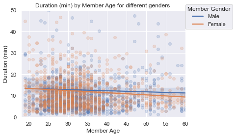

```python
sb.regplot(data= trips_clean.query('member_gender == "Male"').sample(1000), x= 'member_age', y='duration',
           scatter_kws= {'alpha': 0.2})
sb.regplot(data= trips_clean.query('member_gender == "Female"').sample(1000), x= 'member_age', y='duration',
           scatter_kws= {'alpha': 0.2})

plt.ylim(0,50)
plt.ylabel('Duration (min)')

plt.xlim(18,60)
plt.xlabel('Member Age')

plt.title('Duration (min) by Member Age for different genders ')
plt.legend(loc = [1,0.825], title= 'Member Gender', labels= ['Male', 'Female']);
```

## the relation between start day, member gender and trip duration

- the figure emphasize that females have longer trips than males (across all different days)

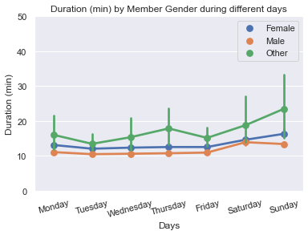

```python
sb.pointplot(data = trips_clean, x = 'start_day', y = 'duration', hue = 'member_gender',order=days_order)

plt.ylim(0,50)
plt.ylabel('Duration (min)')

plt.xticks(rotation=15)
plt.xlabel('Days');

plt.title('Duration (min) by Member Gender during different days')
plt.legend();
```

## the relation between trip start hour, member gender and trip duration

- the figure emphasize that females on average have slightly longer trips than males.
- the figure shows unexpected increase in females trip duration between 1am and 4am , on average 2 times males trip duration.

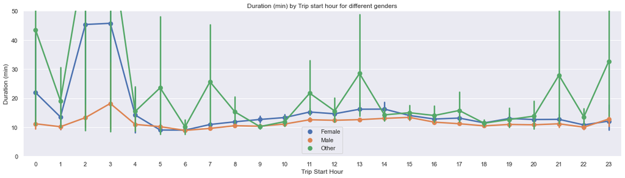

```python
plt.figure(figsize=[20, 5])
sb.pointplot(data= trips_clean, x = 'start_hour', y= 'duration', hue= 'member_gender')

plt.ylim(0,50)
plt.ylabel('Duration (min)')

plt.xlabel('Trip Start Hour')

plt.title('Duration (min) by Trip start hour for different genders')
plt.legend();
```

```python
trips_clean.loc[trips_clean['start_hour'].between(1,4)].groupby('member_gender')['duration'].mean()
```

```
member_gender
Female    23.211247
Male      12.221043
Other     44.388182
Name: duration, dtype: float64
```

## the relation between user type, start hour and start day

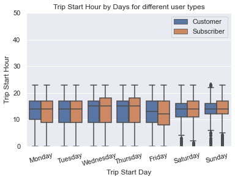

```python
sb.boxplot(data= trips_clean, x = 'start_day', y= 'start_hour', hue= 'user_type',order=days_order)
plt.ylim(0,50)
plt.ylabel('Trip Start Hour')

plt.xticks(rotation=15)
plt.xlabel('Trip Start Day')
plt.title('Trip Start Hour by Days for different user types')
plt.legend();
```

### Were there any interesting or surprising interactions between features?

- the only unexpected interaction noticed in this part was in relation between start_time , member gender and trip duration where there are increase in females trip durations between 1am and 4am.

## References :

- For Calculating distance and apllying function on df
  - https://www.kite.com/python/answers/how-to-find-the-distance-between-two-lat-long-coordinates-in-python
  - https://stackoverflow.com/questions/19412462/getting-distance-between-two-points-based-on-latitude-longitude
  - https://stackoverflow.com/questions/13331698/how-to-apply-a-function-to-two-columns-of-pandas-dataframe
- For pie Charts
  - https://stackoverflow.com/questions/35488666/matplotlib-pandas-pie-chart-label-mistakes
- Changing labels in Factgrid
  - https://stackoverflow.com/questions/36573789/python-seaborn-facetgrid-change-xlabels